# Testing BMS with large data

Joel Eliason

March 19, 2018

Here I will be testing:

- BMS with 100 ICs, equally spaced
- Random noise added for numerical stability (against collinearity)
- Identical shift added for numerical stability (against collinearity)

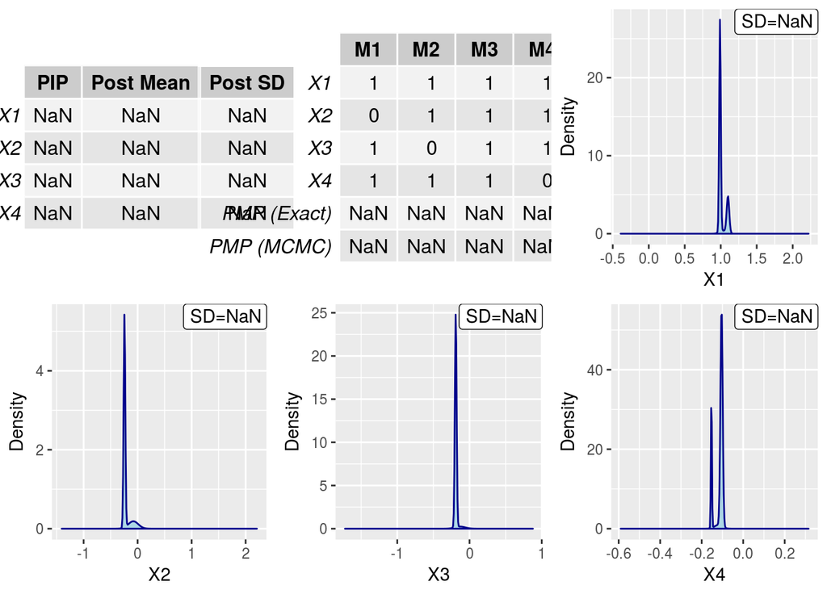

```r
set.seed(123)
step=.01
tf=1
sd=0.1
degree=4
times=seq(0,tf,by=step)
x0=1

ic_step=0.02
ic_f=2
ics=seq(0.01,ic_f,by=ic_step)

df<-lapply(ics, function(z) simple1dsolve(x0=z,step=step,tf=tf,sd=sd,degree=degree))
df<-do.call("rbind",df)

# nrow(df)
# df
bms_summary(x0=x0,step=step,tf=tf,sd=sd,degree=degree,df=df)
```

```r
kappa(df)
```

```
## [1] 683.6065
```

```r
solve(t(as.matrix(df))%*%as.matrix(df))
```

```
##               y1          X1            X2           X3           X4
## y1  0.0099352017 -0.01020565  0.0007904991  0.001286432  0.001188787
## X1 -0.0102056457  0.05882647 -0.1307991187  0.106542640 -0.029514965
## X2  0.0007904991 -0.13079912  0.3721904502 -0.321520024  0.086959987
## X3  0.0012864319  0.10654264 -0.3215200244  0.286117422 -0.078748039
## X4  0.0011887870 -0.02951497  0.0869599875 -0.078748039  0.022281371
```

So this doesn’t work. Let’s try turning up the noise a little bit:

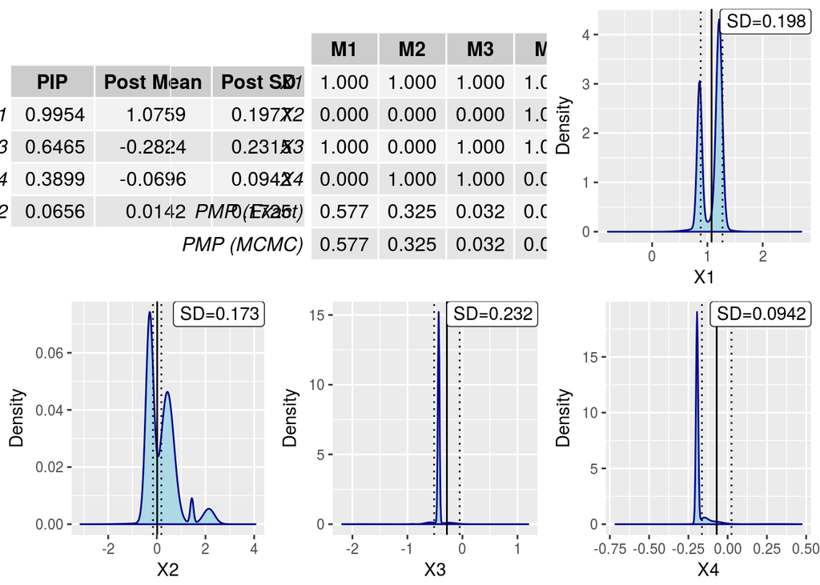

```r
sd=1
df<-lapply(ics, function(z) simple1dsolve(x0=z,step=step,tf=tf,sd=sd,degree=degree))
df<-do.call("rbind",df)
bms_summary(x0=x0,step=step,tf=tf,sd=sd,degree=degree,df=df)
```

```r
kappa(df)
```

```
## [1] 856.168
```

Nailed it. And look at those probabilities. (However, the top model doesn’t match). Just to get an idea of what’s happening, this particular BMA method uses Zellner’s g-priors, which assumes that the regression coefficients have the same covariance structure as the regressors (which is a decent enough hypothesis). However, when the regressors are highly collinear, this can definitely become an issue, since this covariance structure pushes the coefficients of highly collinear regressors in opposite directions - not something that you really want. In this case, it may be better to use independent normal priors for each coefficient (this is essentially synonymous to doing ridge regression, something that we know handles multicollinearity quite well).

Instead of noise, let’s try adding a constant $\lambda$ to each y, to see if that also corrects the numerical instability.

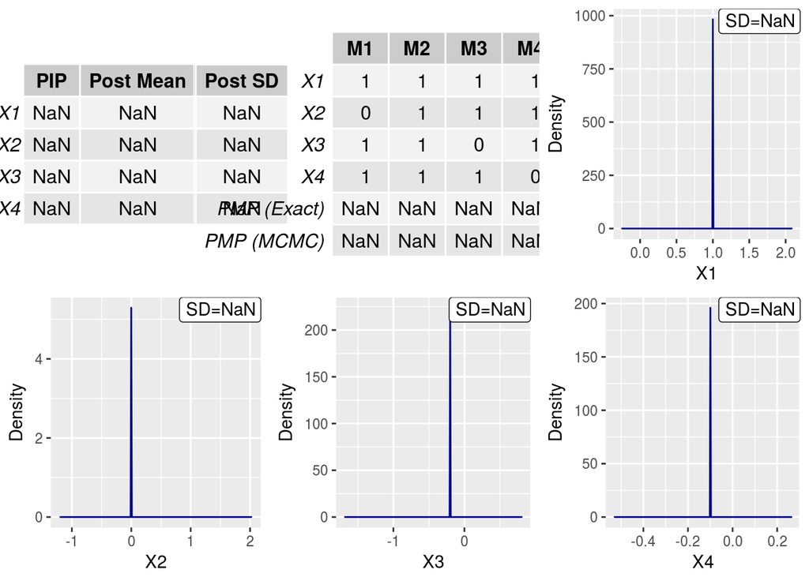

```r
sd=0
df<-lapply(ics, function(z) simple1dsolve(x0=z,step=step,tf=tf,sd=sd,degree=degree))
df<-do.call("rbind",df)
df$y1<-df$y1+5
bms_summary(x0=x0,step=step,tf=tf,sd=sd,degree=degree,df=df)
```

```r
kappa(df)
```

```
## [1] 1476.474
```

This doesn’t work.

```r
sd=1
ic_step=0.2
ic_f=5
ics=seq(0.01,ic_f,by=ic_step)

df<-lapply(ics, function(z) simple1dsolve(x0=z,step=step,tf=tf,sd=sd,degree=degree))
df<-do.call("rbind",df)
cor(df)
```

```
##            y1         X1         X2         X3         X4
## y1  1.0000000 -0.5808523 -0.8168187 -0.9329611 -0.9636074
## X1 -0.5808523  1.0000000  0.9237993  0.7803088  0.6415453
## X2 -0.8168187  0.9237993  1.0000000  0.9549018  0.8651045
## X3 -0.9329611  0.7803088  0.9549018  1.0000000  0.9729049
## X4 -0.9636074  0.6415453  0.8651045  0.9729049  1.0000000
```

```r
df[,2:ncol(df)]<-scale(df[,2:ncol(df)],scale=F)
cor(df)
```

```
##            y1         X1         X2         X3         X4
## y1  1.0000000 -0.5808523 -0.8168187 -0.9329611 -0.9636074
## X1 -0.5808523  1.0000000  0.9237993  0.7803088  0.6415453
## X2 -0.8168187  0.9237993  1.0000000  0.9549018  0.8651045
## X3 -0.9329611  0.7803088  0.9549018  1.0000000  0.9729049
## X4 -0.9636074  0.6415453  0.8651045  0.9729049  1.0000000
```

```r
nrow(df)
```

```
## [1] 2525
```

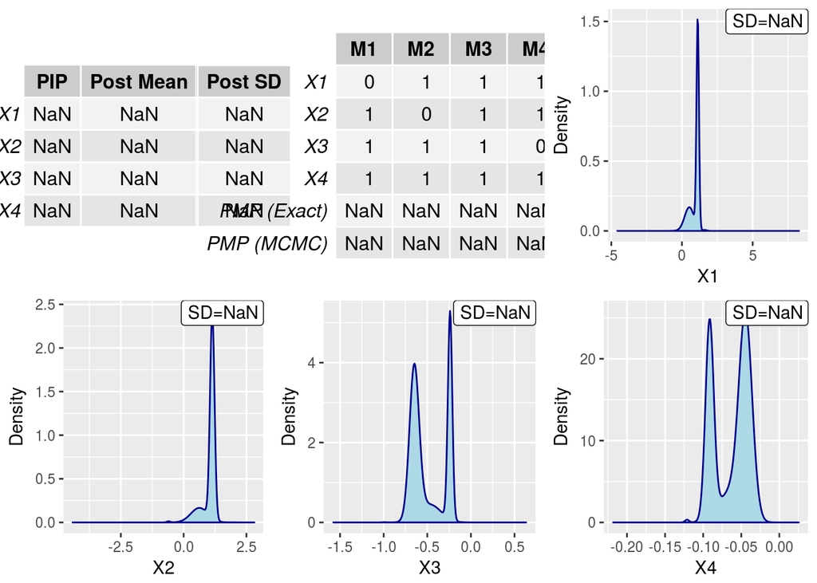

```r
# df
bms_summary(x0=x0,step=step,tf=tf,sd=sd,degree=degree,df=df)
```

This doesn’t work very well. So we may either need to find a different prior (one without the covariance structure of the regressors), or one where we can directly tweak the numerical stability of the design matrix. Both seem to be related to ridge regression. This may involve the use of the BAS package.

Let’s check out the eigenvalues and $\kappa$ of that last design matrix before we move on.

```r
rcond(as.matrix(df))
```

```
## [1] 0.0006293866
```

```r
eigen(t(as.matrix(df))%*%as.matrix(df))
```

```
## eigen() decomposition
## $values
## [1] 2.108938e+06 1.002894e+04 4.921382e+03 1.872055e+02 4.323942e+00
##
## $vectors
##             [,1]       [,2]         [,3]        [,4]          [,5]
## [1,]  0.13111236 -0.1604454  0.977632799 -0.03606823 -0.0001749457
## [2,] -0.01446476 -0.2233306 -0.008902766  0.70284362 -0.6751635445
## [3,] -0.06371894 -0.5096555 -0.056447034  0.50215197  0.6934322579
## [4,] -0.24819329 -0.7853212 -0.113949312 -0.49619639 -0.2499508542
## [5,] -0.95757000  0.2188667  0.167284601  0.07963968  0.0288172126
```

Let’s try out BAS with the same dataset and see how we do:

```r
fit<-bas.lm(y1~.,data=df)
fit
```

```
##
## Call:
## bas.lm(formula = y1 ~ ., data = df)
##
##
##  Marginal Posterior Inclusion Probabilities:
## Intercept         X1         X2         X3         X4
##    1.0000     0.4340     0.6487     0.9978     0.9995
```

```r
summary(fit)
```

```
##           P(B != 0 | Y)   model 1      model 2      model 3      model 4
## Intercept     1.0000000    1.0000    1.0000000 1.000000e+00 1.000000e+00
## X1            0.4340179    0.0000    1.0000000 1.000000e+00 1.000000e+00
## X2            0.6486836    1.0000    0.0000000 1.000000e+00 1.000000e+00
## X3            0.9977900    1.0000    1.0000000 1.000000e+00 0.000000e+00
## X4            0.9995465    1.0000    1.0000000 1.000000e+00 1.000000e+00
## BF                   NA    1.0000    0.6208167 3.539806e-02 3.905408e-03
## PostProbs            NA    0.5659    0.3513000 8.010000e-02 2.200000e-03
## R2                   NA    0.9333    0.9333000 9.334000e-01 9.330000e-01
## dim                  NA    4.0000    4.0000000 5.000000e+00 4.000000e+00
## logmarg              NA 3400.4865 3400.0098147 3.397145e+03 3.394941e+03
##                model 5
## Intercept 1.000000e+00
## X1        1.000000e+00
## X2        1.000000e+00
## X3        1.000000e+00
## X4        0.000000e+00
## BF        6.455717e-04
## PostProbs 4.000000e-04
## R2        9.329000e-01
## dim       4.000000e+00
## logmarg   3.393141e+03
```

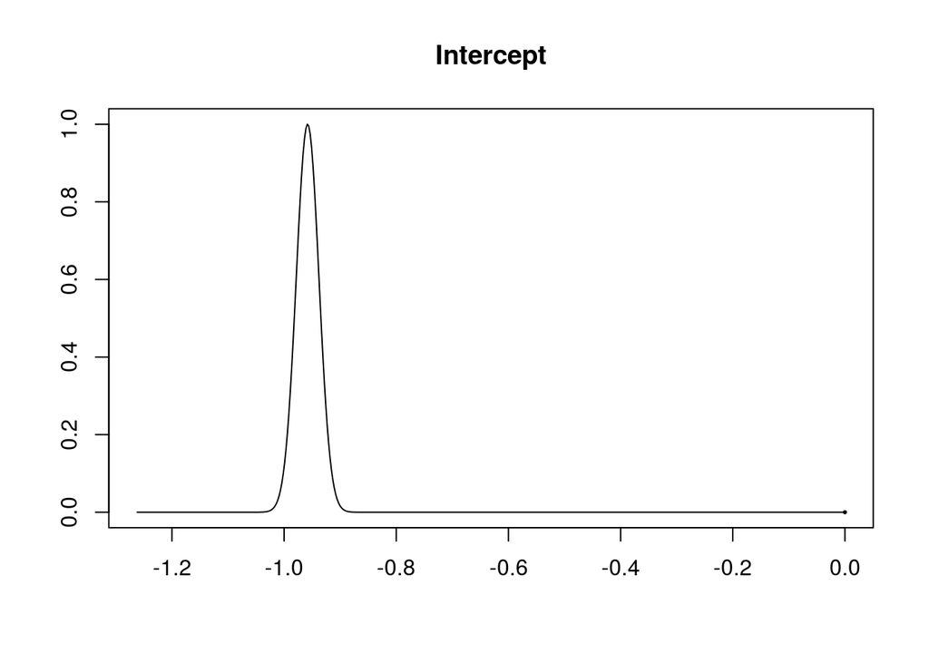

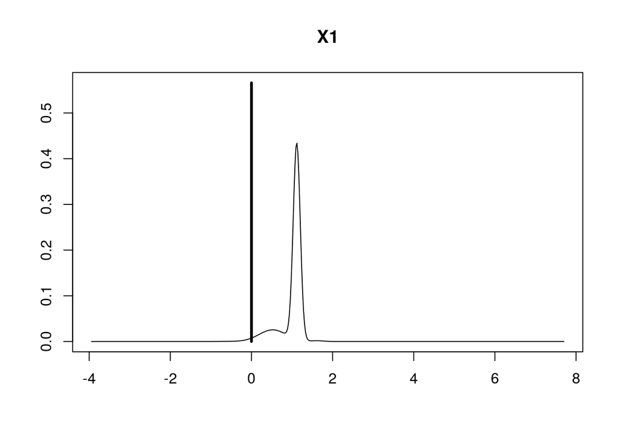

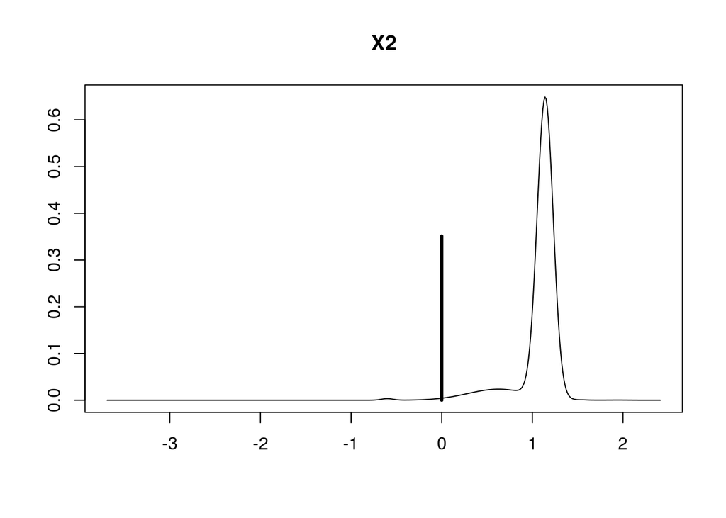

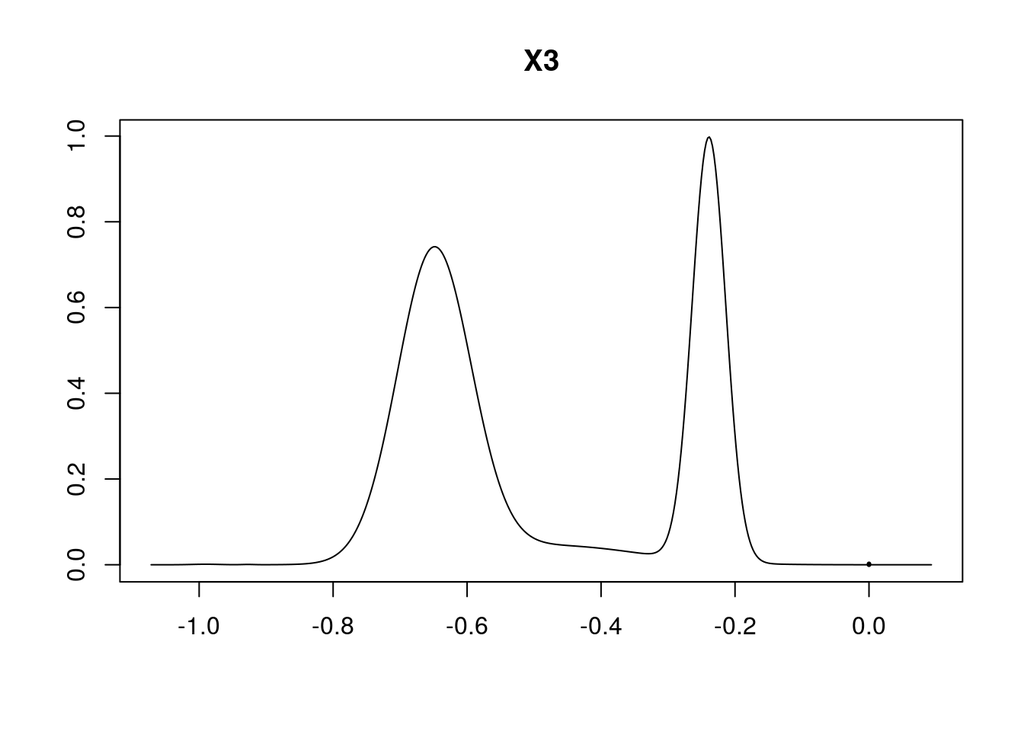

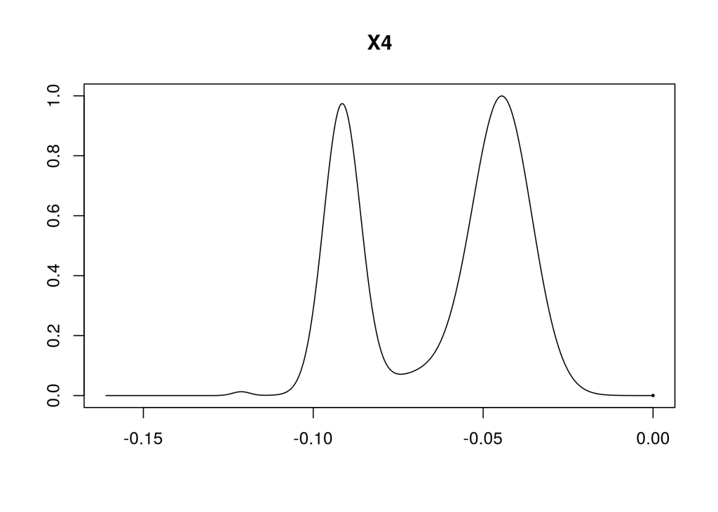

```r
coef.fit=coef(fit)
plot(coef.fit,ask=F)
```

That cleans things right up. However, it picks the wrong top model. Let’s try with that earlier set of ICs again.

```r
ic_step=0.02
ic_f=2
ics=seq(0.01,ic_f,by=ic_step)

df<-lapply(ics, function(z) simple1dsolve(x0=z,step=step,tf=tf,sd=sd,degree=degree))
df<-do.call("rbind",df)
# cor(df)
df[,2:ncol(df)]<-scale(df[,2:ncol(df)],scale=F)

fit<-bas.lm(y1~.,data=df)
fit
```

```
##
## Call:
## bas.lm(formula = y1 ~ ., data = df)
##
##
##  Marginal Posterior Inclusion Probabilities:
## Intercept         X1         X2         X3         X4
##   1.00000    0.99984    0.09004    0.84781    0.19584
```

```r
summary(fit)
```

```
##           P(B != 0 | Y)  model 1     model 2      model 3      model 4
## Intercept    1.00000000   1.0000   1.0000000   1.00000000   1.00000000
## X1           0.99984058   1.0000   1.0000000   1.00000000   1.00000000
## X2           0.09004429   0.0000   0.0000000   1.00000000   0.00000000
## X3           0.84780761   1.0000   0.0000000   0.00000000   1.00000000
## X4           0.19584483   0.0000   1.0000000   1.00000000   1.00000000
## BF                   NA   1.0000   0.1207054   0.04974809   0.03144655
## PostProbs            NA   0.7792   0.0940000   0.05810000   0.03680000
## R2                   NA   0.0841   0.0837000   0.08430000   0.08420000
## dim                  NA   3.0000   3.0000000   4.00000000   4.00000000
## logmarg              NA 433.5993 431.4848673 430.59848635 430.13980347
##                model 5
## Intercept   1.00000000
## X1          1.00000000
## X2          1.00000000
## X3          1.00000000
## X4          0.00000000
## BF          0.02135474
## PostProbs   0.02500000
## R2          0.08410000
## dim         4.00000000
## logmarg   429.75278823
```

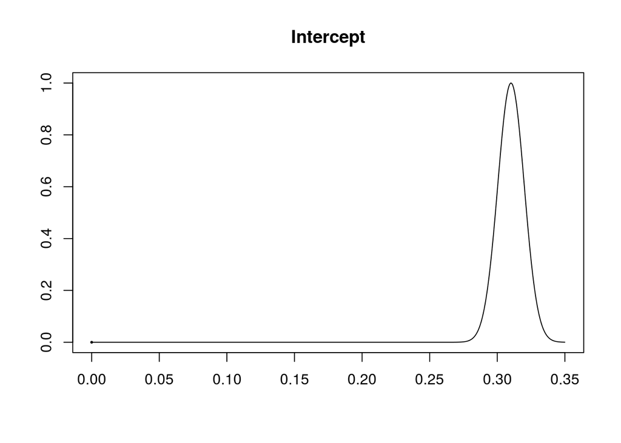

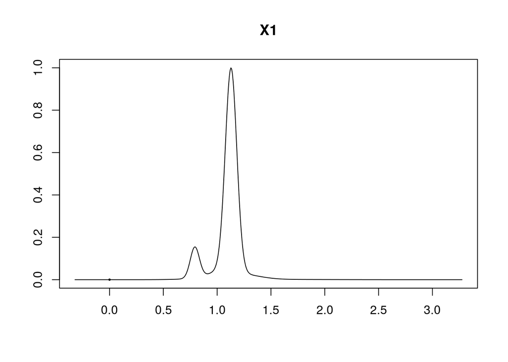

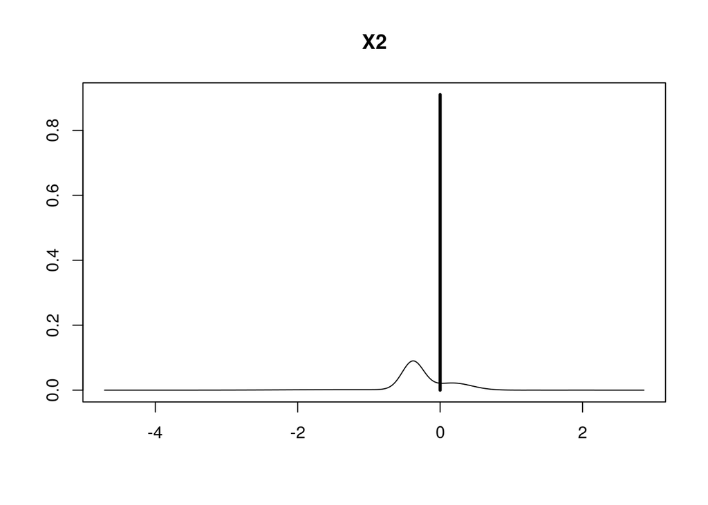

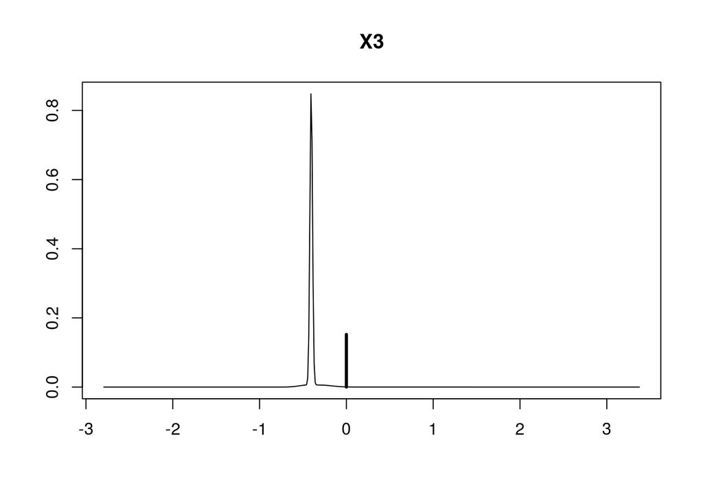

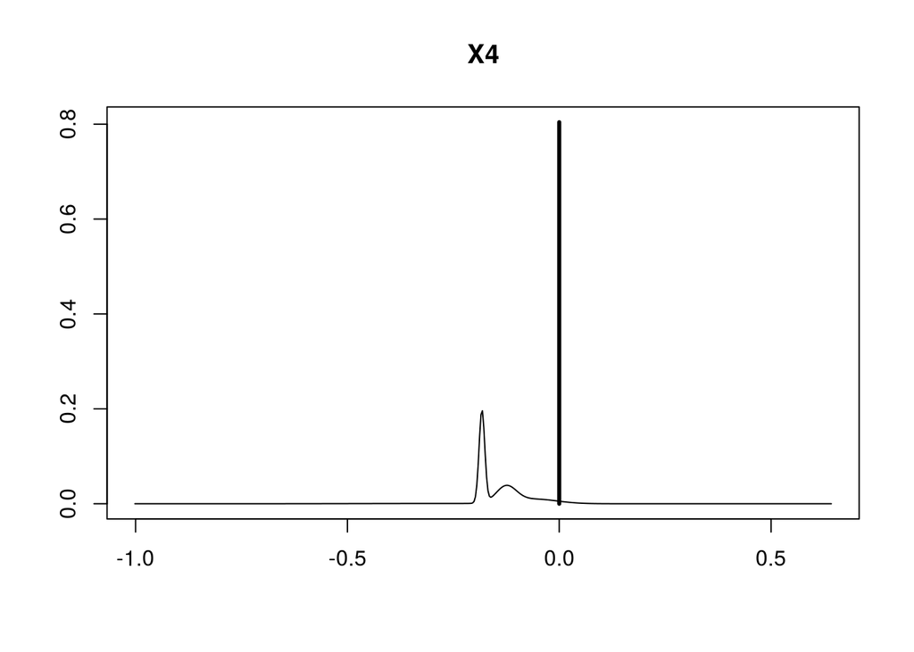

```r
coef.fit=coef(fit)
plot(coef.fit,ask=F)
```

Again, wrong. Let’s change the density of ICs to 10x more.

```r
ic_step=0.002
ic_f=2
ics=seq(0.01,ic_f,by=ic_step)

df<-lapply(ics, function(z) simple1dsolve(x0=z,step=step,tf=tf,sd=sd,degree=degree))
df<-do.call("rbind",df)
nrow(df)
```

```
## [1] 100596
```

```r
df[,2:ncol(df)]<-scale(df[,2:ncol(df)],scale=F)

fit<-bas.lm(y1~.,data=df)
fit
```

```
##
## Call:
## bas.lm(formula = y1 ~ ., data = df)
##
##
##  Marginal Posterior Inclusion Probabilities:
## Intercept         X1         X2         X3         X4
##    1.0000     1.0000     0.7433     0.2881     0.9887
```

```r
summary(fit)
```

```
##           P(B != 0 | Y)   model 1      model 2      model 3      model 4
## Intercept     1.0000000    1.0000    1.0000000 1.000000e+00 1.000000e+00
## X1            1.0000000    1.0000    1.0000000 1.000000e+00 1.000000e+00
## X2            0.7432839    1.0000    0.0000000 1.000000e+00 1.000000e+00
## X3            0.2881018    0.0000    1.0000000 1.000000e+00 1.000000e+00
## X4            0.9887060    1.0000    1.0000000 1.000000e+00 0.000000e+00
## BF                   NA    1.0000    0.3605147 7.079120e-03 1.577264e-02
## PostProbs            NA    0.7119    0.2566000 2.020000e-02 1.120000e-02
## R2                   NA    0.0854    0.0854000 8.540000e-02 8.540000e-02
## dim                  NA    4.0000    4.0000000 5.000000e+00 4.000000e+00
## logmarg              NA 4474.2666 4473.2463565 4.469316e+03 4.470117e+03
##                model 5
## Intercept 1.000000e+00
## X1        1.000000e+00
## X2        0.000000e+00
## X3        1.000000e+00
## X4        0.000000e+00
## BF        1.380991e-04
## PostProbs 1.000000e-04
## R2        8.520000e-02
## dim       3.000000e+00
## logmarg   4.465379e+03
```

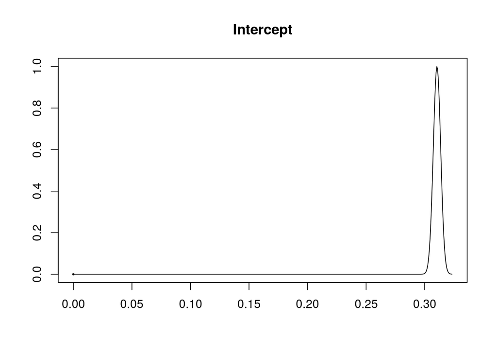

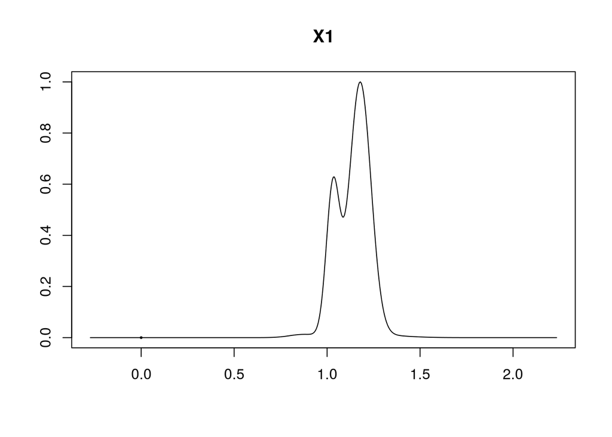

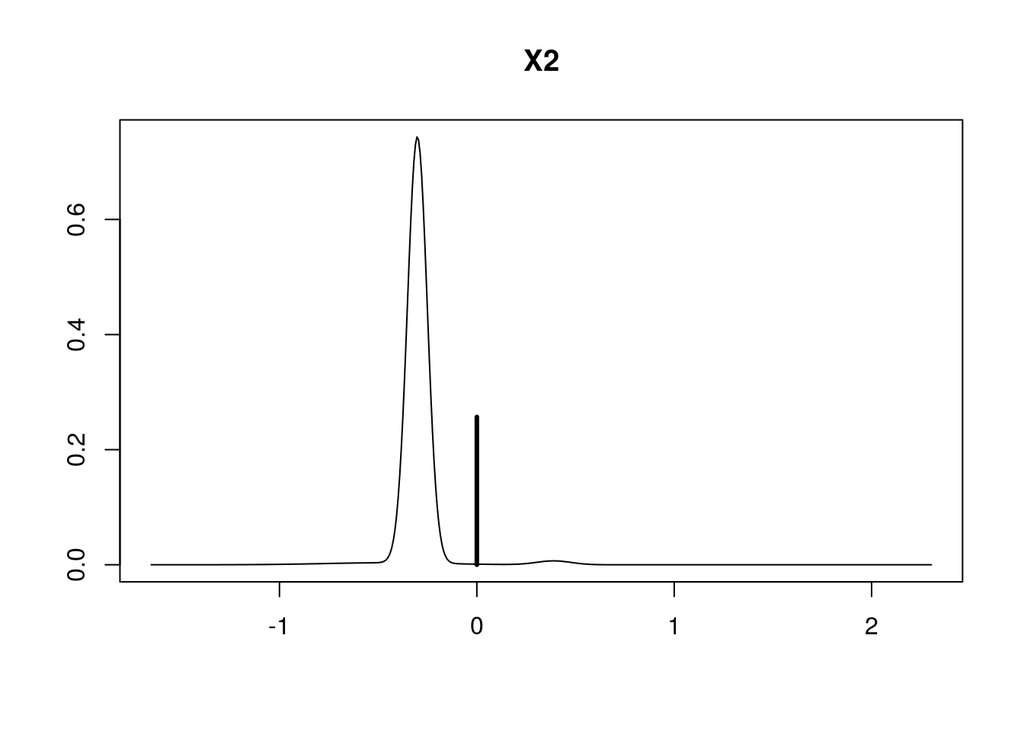

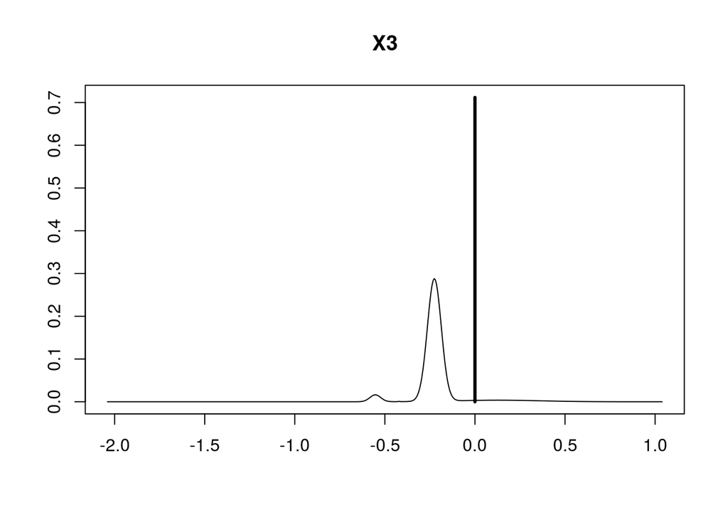

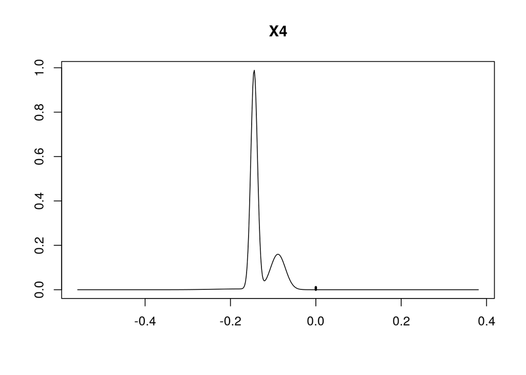

```r
coef.fit=coef(fit)
plot(coef.fit,ask=F)
```

This is correct. I wonder if we’ll get the same results if we just take 10x as many points:

```r
ic_step=0.02
ic_f=2
ics=seq(0.01,ic_f,by=ic_step)
tf=10
df<-lapply(ics, function(z) simple1dsolve(x0=z,step=step,tf=tf,sd=sd,degree=degree))
df<-do.call("rbind",df)
nrow(df)
```

```
## [1] 100100
```

```r
df[,2:ncol(df)]<-scale(df[,2:ncol(df)],scale=F)

fit<-bas.lm(y1~.,data=df)
fit
```

```
##
## Call:
## bas.lm(formula = y1 ~ ., data = df)
##
##
##  Marginal Posterior Inclusion Probabilities:
## Intercept         X1         X2         X3         X4
##   1.00000    0.96082    0.05850    0.05961    0.95243
```

```r
summary(fit)
```

```
##           P(B != 0 | Y)   model 1      model 2      model 3      model 4
## Intercept    1.00000000    1.0000 1.000000e+00 1.000000e+00 1.000000e+00
## X1           0.96082359    1.0000 0.000000e+00 1.000000e+00 1.000000e+00
## X2           0.05850208    0.0000 1.000000e+00 1.000000e+00 0.000000e+00
## X3           0.05960661    0.0000 1.000000e+00 1.000000e+00 1.000000e+00
## X4           0.95243276    1.0000 0.000000e+00 0.000000e+00 1.000000e+00
## BF                   NA    1.0000 3.892152e-02 7.635596e-03 6.329246e-03
## PostProbs            NA    0.9320 3.630000e-02 1.070000e-02 8.800000e-03
## R2                   NA    0.0294 2.930000e-02 2.940000e-02 2.940000e-02
## dim                  NA    3.0000 3.000000e+00 4.000000e+00 4.000000e+00
## logmarg              NA 1479.0367 1.475790e+03 1.474162e+03 1.473974e+03
##                model 5
## Intercept 1.000000e+00
## X1        1.000000e+00
## X2        1.000000e+00
## X3        0.000000e+00
## X4        1.000000e+00
## BF        5.979916e-03
## PostProbs 8.400000e-03
## R2        2.940000e-02
## dim       4.000000e+00
## logmarg   1.473917e+03
```

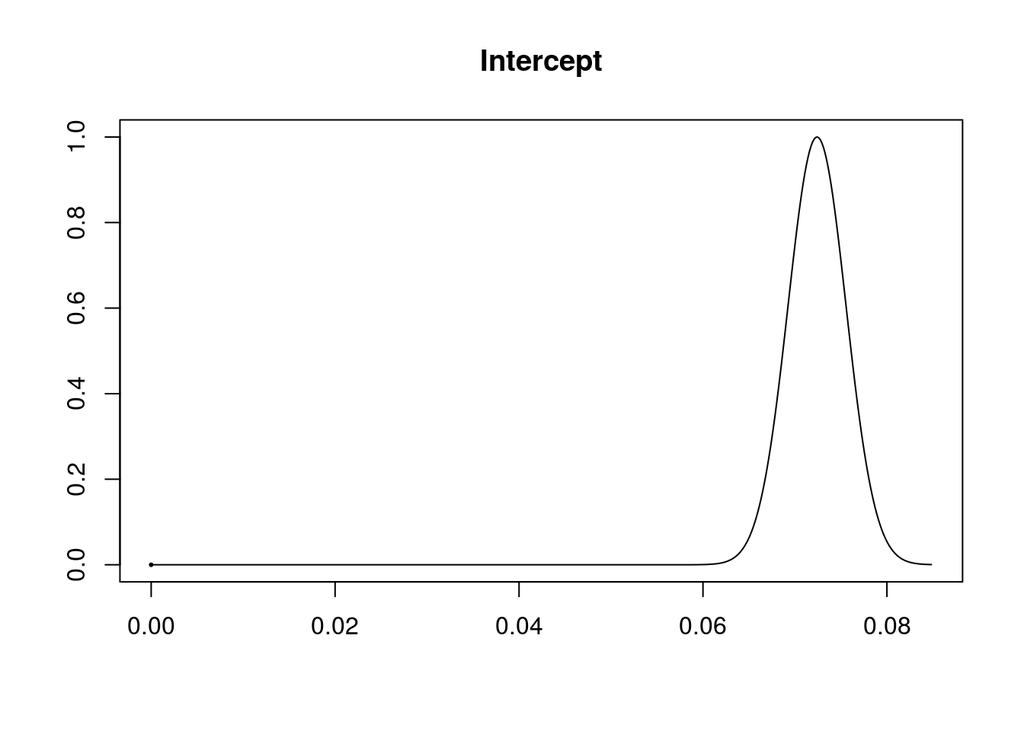

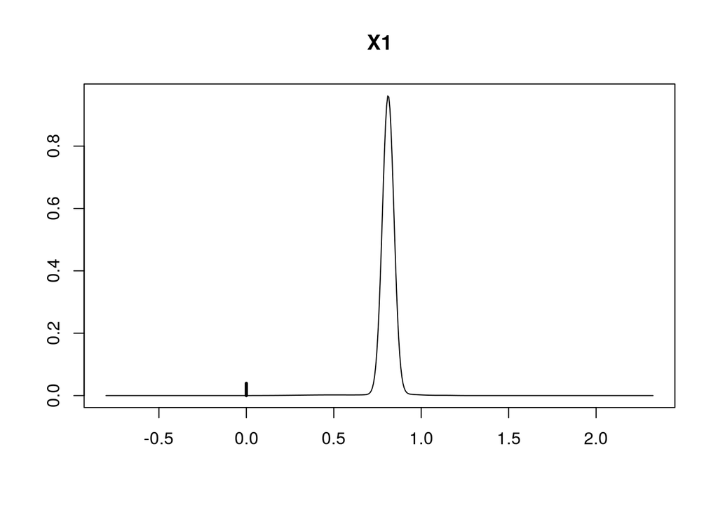

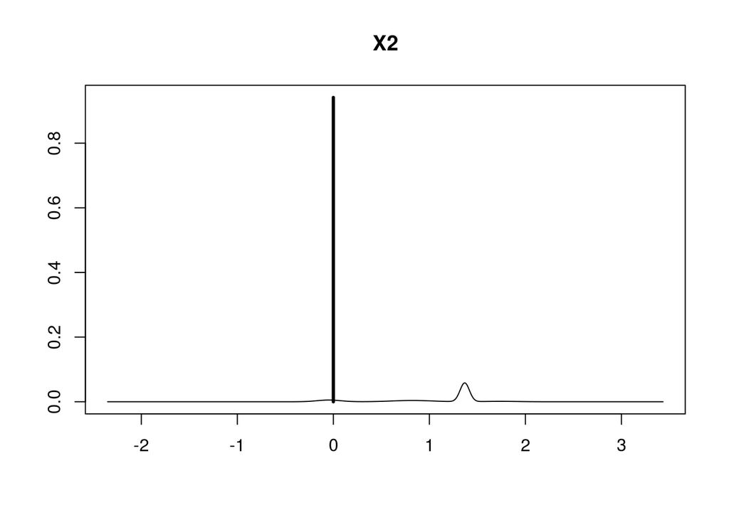

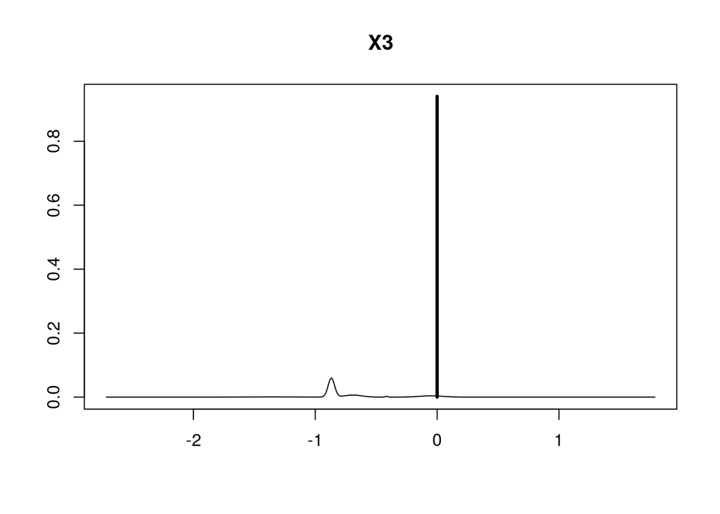

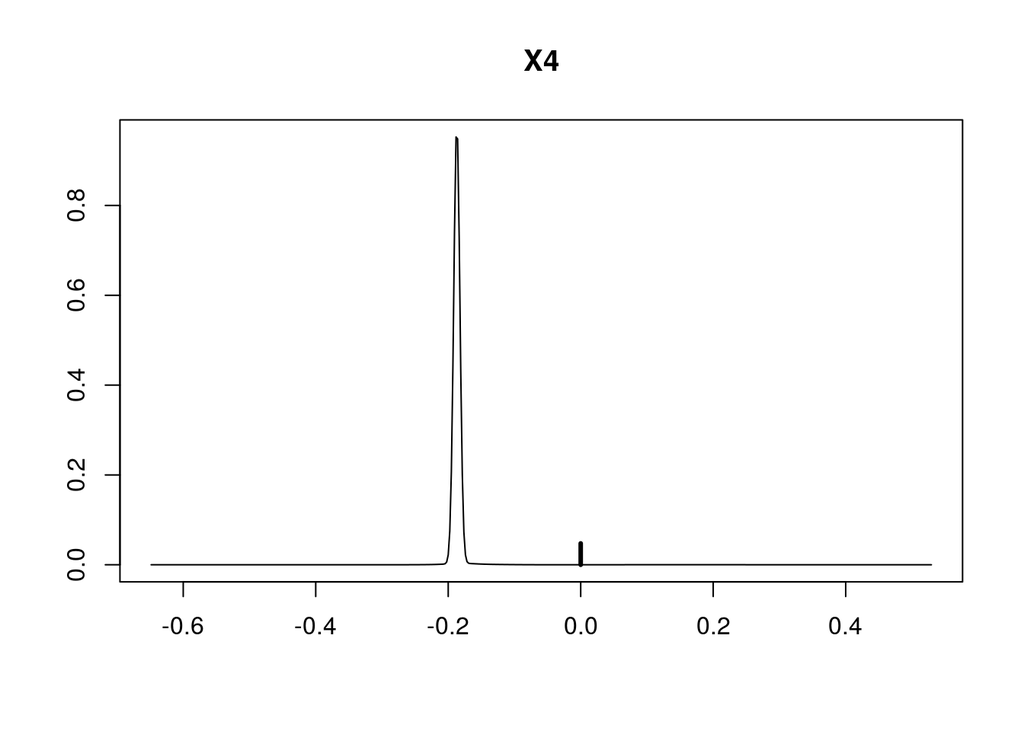

```r
coef.fit=coef(fit)
plot(coef.fit,ask=F)
```

Next, let’s try centering before we create the polynomial terms, to see if that helps either algorithm. I’ve added a center option to simple1dsolve.